# 2

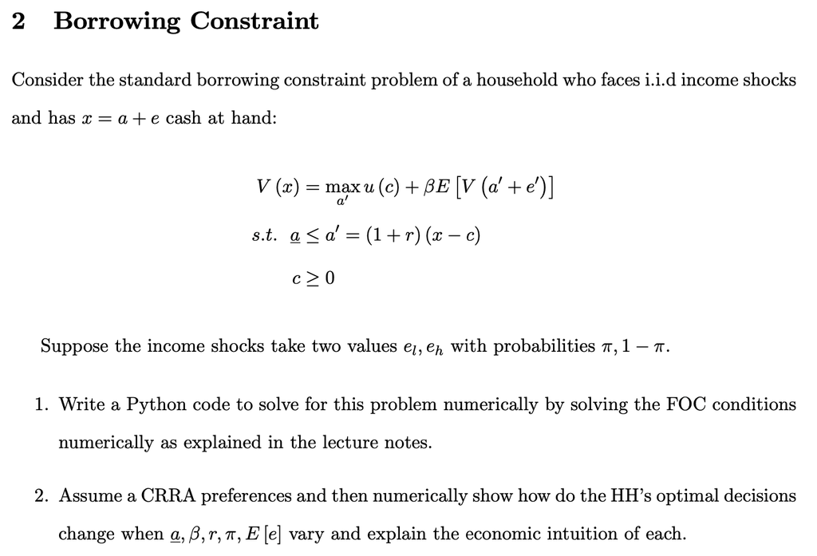

### In the lecture notes, this problem was solved with value function iteration. So we use value function iteration.

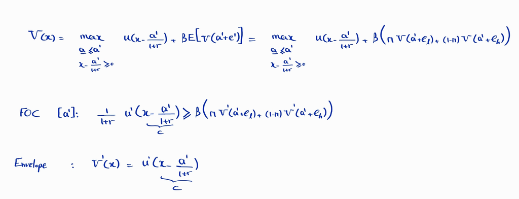

```python
from joblib import Parallel, delayed
import numpy as np
from numpy import interp
from scipy.optimize import fsolve, fminbound
import matplotlib.pyplot as plt
import seaborn as sns
import tqdm
import pandas as pd
```

```python
α, β, A, σ = 0.3, 0.96, 0.1, 0.3
r = 0.039925 # < 0.0416 = 1 / β - 1
expexted_e, var_e = 0.7, 0.4
e_l, e_h = expexted_e - var_e, expexted_e + var_e
π = 0.2
a_constraint = 0.8
φ = min(a_constraint, e_l / r)
print(a_constraint, ' < ', e_l / r)
```

```
0.8  <  7.514088916718846
```

```python
from numpy import array as np_array
# Importing increases performance of Parallel!


def U(c):
    return c ** (1 - σ) / (1 - σ)


def value_func_iterate(x_grid, v0_grid):
    # x=x in lambda!
    # Evaluation Time
    # https://realpython.com/python-lambda/
    F=lambda x, y: U(x - y / (1 + r))
    y_grid = np_array(Parallel(n_jobs=n_jobs, verbose=0, return_as='list', batch_size=grid_size // n_jobs)(
        delayed(fminbound)(func=lambda y, x=x: -(F(x, y) + β * (π * interp(y + e_l, x_grid, v0_grid) + (1 - π) * interp(y + e_h, x_grid, v0_grid))), x1 = -φ, x2 = (1 + r) * x) for x in
        x_grid))
    v_grid_updated = np_array(F(x_grid, y_grid) + β * (π * interp(y_grid + e_l, x_grid, v0_grid) + (1 - π) * interp(y_grid + e_h, x_grid, v0_grid)))

    return y_grid, v_grid_updated
```

```python
%%time

n_jobs = 14
grid_size = 1_000
current_x_grid = np.linspace(-φ + e_l, 5, grid_size)
next_a_grid = np.linspace(-φ, 5 * 0.8, grid_size)
current_c_grid = current_x_grid - next_a_grid / (1 + r)
v_grid = U(current_c_grid) / (1 - β)


max_iter = 200
tol = 10 ** -4
for _ in tqdm.tqdm(range(max_iter), ncols=50):
    g, v_grid = value_func_iterate(x_grid=current_x_grid, v0_grid=v_grid)
    err = np.max(np.abs(g - next_a_grid))
    next_a_grid = g
    if err < tol:
        break
current_c_grid = current_x_grid - next_a_grid / (1 + r)
```

```
CPU times: user 8.83 s, sys: 1.37 s, total: 10.2 s
Wall time: 10.8 s
```

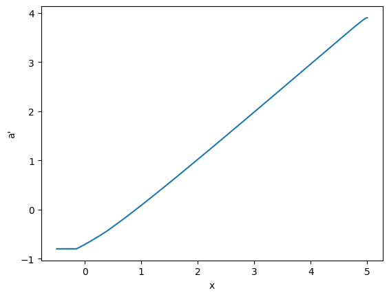

```python
# Policy Function
sns.lineplot(x=current_x_grid, y=next_a_grid)
plt.xlabel('x')
plt.ylabel("a'");
```

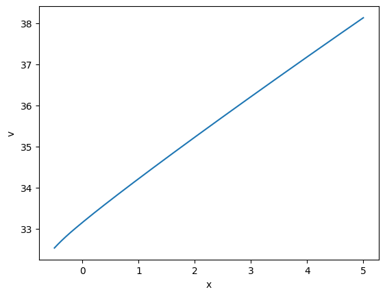

```python
# Value Function
sns.lineplot(x=current_x_grid, y=v_grid)
plt.xlabel('x')
plt.ylabel("v");
```

```
r1: 0.03993, r2: 0.03998
```

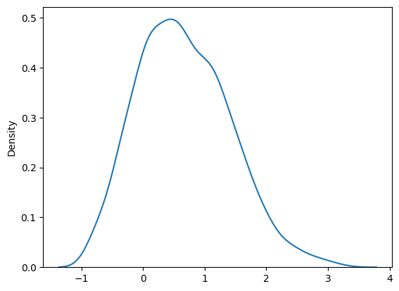

```python
np.random.seed(1400)
S = 1000
sim_current_a = np.random.uniform(-φ, 5 - e_h, S)

for _ in range(100):
    sim_e = e_l + (np.random.random(size=S) < 1 - π) * var_e * 2
    sim_current_x = sim_current_a + sim_e
    sim_next_a = interp(sim_current_x, current_x_grid, next_a_grid)
    sim_current_a = sim_next_a

sns.kdeplot(sim_current_a);
print(f'r1: {r:.4}, r2: {α * A * sim_current_a.mean()**(α-1):.4}')
```

### By iteration, I chose different r and then computed r2, and tried to find the general equilibrium r such that r1=r2.

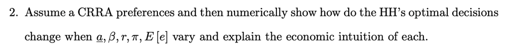

```python
original_next_a_grid, original_v_grid = next_a_grid, v_grid
```

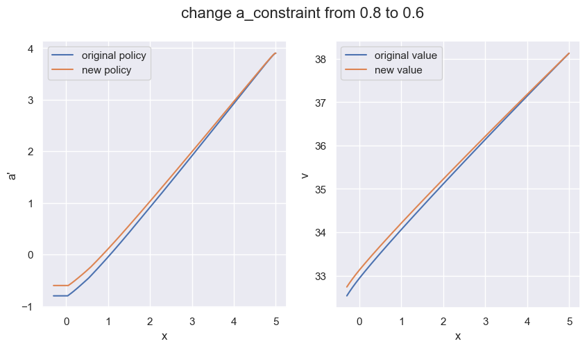

```python
α, β, A, σ = 0.3, 0.96, 0.1, 0.3
r = 0.039925
expexted_e, var_e = 0.7, 0.4
e_l, e_h = expexted_e - var_e, expexted_e + var_e
π = 0.2
a_constraint = 0.6
φ = min(a_constraint, e_l / r)


current_x_grid = np.linspace(-φ + e_l, 5, grid_size)
next_a_grid = np.linspace(-φ, 5 * 0.8, grid_size)
current_c_grid = current_x_grid - next_a_grid / (1 + r)
v_grid = U(current_c_grid) / (1 - β)


for _ in tqdm.tqdm(range(max_iter), ncols=50):
    g, v_grid = value_func_iterate(x_grid=current_x_grid, v0_grid=v_grid)
    err = np.max(np.abs(g - next_a_grid))
    next_a_grid = g
    if err < tol:
        break


d = pd.DataFrame([current_x_grid, original_next_a_grid, next_a_grid, original_v_grid, v_grid], index=['x', 'original policy', 'new policy', 'original value', 'new value']).T.set_index('x')

sns.set(rc={'figure.figsize': (10, 5)})
fig, axs = plt.subplots(ncols=2, nrows=1)
d[['original policy', 'new policy']].plot(ax=axs[0])
axs[0].set_ylabel("a'")
d[['original value', 'new value']].plot(ax=axs[1])
axs[1].set_ylabel("v")
fig.suptitle('change a_constraint from 0.8 to 0.6', fontsize=16);
```

- decreasing a_constraint means the constraint is more strict, so the policy function should increase and is increased. Also the value function should decrease, however it is increased! why?

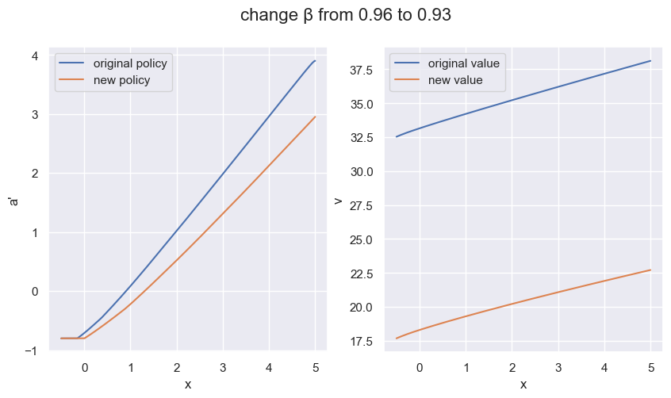

```python
α, β, A, σ = 0.3, 0.93, 0.1, 0.3
r = 0.039925
expexted_e, var_e = 0.7, 0.4
e_l, e_h = expexted_e - var_e, expexted_e + var_e
π = 0.2
a_constraint = 0.8
φ = min(a_constraint, e_l / r)


current_x_grid = np.linspace(-φ + e_l, 5, grid_size)
next_a_grid = np.linspace(-φ, 5 * 0.8, grid_size)
current_c_grid = current_x_grid - next_a_grid / (1 + r)
v_grid = U(current_c_grid) / (1 - β)


for _ in tqdm.tqdm(range(max_iter), ncols=50):
    g, v_grid = value_func_iterate(x_grid=current_x_grid, v0_grid=v_grid)
    err = np.max(np.abs(g - next_a_grid))
    next_a_grid = g
    if err < tol:
        break


d = pd.DataFrame([current_x_grid, original_next_a_grid, next_a_grid, original_v_grid, v_grid], index=['x', 'original policy', 'new policy', 'original value', 'new value']).T.set_index('x')

sns.set(rc={'figure.figsize': (10, 5)})
fig, axs = plt.subplots(ncols=2, nrows=1)
d[['original policy', 'new policy']].plot(ax=axs[0])
axs[0].set_ylabel("a'")
d[['original value', 'new value']].plot(ax=axs[1])
axs[1].set_ylabel("v")
fig.suptitle('change β from 0.96 to 0.93', fontsize=16);
```

- As the households get less patient, the policy function should decrease, they prefer to consume more today and less in the future. And as they discount more, their value function should decrease.

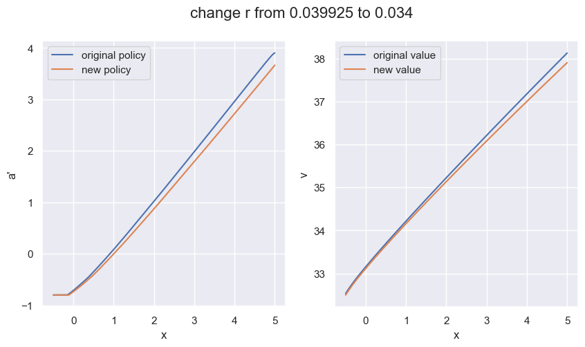

```python
α, β, A, σ = 0.3, 0.96, 0.1, 0.3
r = 0.034
expexted_e, var_e = 0.7, 0.4
e_l, e_h = expexted_e - var_e, expexted_e + var_e
π = 0.2
a_constraint = 0.8
φ = min(a_constraint, e_l / r)


current_x_grid = np.linspace(-φ + e_l, 5, grid_size)
next_a_grid = np.linspace(-φ, 5 * 0.8, grid_size)
current_c_grid = current_x_grid - next_a_grid / (1 + r)
v_grid = U(current_c_grid) / (1 - β)


for _ in tqdm.tqdm(range(max_iter), ncols=50):
    g, v_grid = value_func_iterate(x_grid=current_x_grid, v0_grid=v_grid)
    err = np.max(np.abs(g - next_a_grid))
    next_a_grid = g
    if err < tol:
        break


d = pd.DataFrame([current_x_grid, original_next_a_grid, next_a_grid, original_v_grid, v_grid], index=['x', 'original policy', 'new policy', 'original value', 'new value']).T.set_index('x')

sns.set(rc={'figure.figsize': (10, 5)})
fig, axs = plt.subplots(ncols=2, nrows=1)
d[['original policy', 'new policy']].plot(ax=axs[0])
axs[0].set_ylabel("a'")
d[['original value', 'new value']].plot(ax=axs[1])
axs[1].set_ylabel("v")
fig.suptitle('change r from 0.039925 to 0.034', fontsize=16);
```

- decrease in r, as decreases the return on saving, decreases the policy function. also, it decreases the total wealth of hh and so decreases the value function.

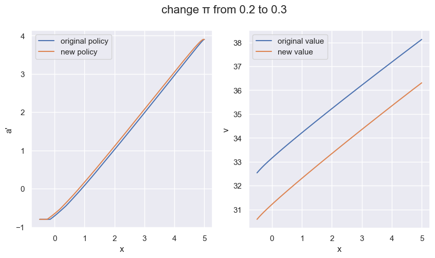

```python
α, β, A, σ = 0.3, 0.96, 0.1, 0.3
r = 0.039925
expexted_e, var_e = 0.7, 0.4
e_l, e_h = expexted_e - var_e, expexted_e + var_e
π = 0.3
a_constraint = 0.8
φ = min(a_constraint, e_l / r)


current_x_grid = np.linspace(-φ + e_l, 5, grid_size)
next_a_grid = np.linspace(-φ, 5 * 0.8, grid_size)
current_c_grid = current_x_grid - next_a_grid / (1 + r)
v_grid = U(current_c_grid) / (1 - β)


for _ in tqdm.tqdm(range(max_iter), ncols=50):
    g, v_grid = value_func_iterate(x_grid=current_x_grid, v0_grid=v_grid)
    err = np.max(np.abs(g - next_a_grid))
    next_a_grid = g
    if err < tol:
        break


d = pd.DataFrame([current_x_grid, original_next_a_grid, next_a_grid, original_v_grid, v_grid], index=['x', 'original policy', 'new policy', 'original value', 'new value']).T.set_index('x')

sns.set(rc={'figure.figsize': (10, 5)})
fig, axs = plt.subplots(ncols=2, nrows=1)
d[['original policy', 'new policy']].plot(ax=axs[0])
axs[0].set_ylabel("a'")
d[['original value', 'new value']].plot(ax=axs[1])
axs[1].set_ylabel("v")
fig.suptitle('change π from 0.2 to 0.3', fontsize=16);
```

- Increase in the probabilty of having low income, increases the policy and decreases the value function.

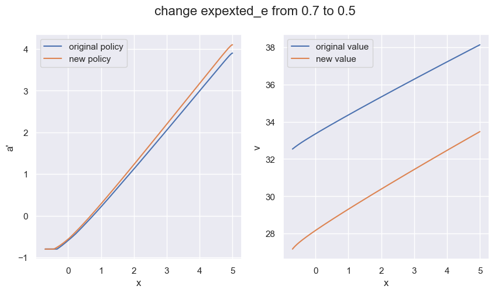

```python
α, β, A, σ = 0.3, 0.96, 0.1, 0.3
r = 0.039925
expexted_e, var_e = 0.5, 0.4
e_l, e_h = expexted_e - var_e, expexted_e + var_e
π = 0.2
a_constraint = 0.8
φ = min(a_constraint, e_l / r)


current_x_grid = np.linspace(-φ + e_l, 5, grid_size)
next_a_grid = np.linspace(-φ, 5 * 0.8, grid_size)
current_c_grid = current_x_grid - next_a_grid / (1 + r)
v_grid = U(current_c_grid) / (1 - β)


for _ in tqdm.tqdm(range(max_iter), ncols=50):
    g, v_grid = value_func_iterate(x_grid=current_x_grid, v0_grid=v_grid)
    err = np.max(np.abs(g - next_a_grid))
    next_a_grid = g
    if err < tol:
        break


d = pd.DataFrame([current_x_grid, original_next_a_grid, next_a_grid, original_v_grid, v_grid], index=['x', 'original policy', 'new policy', 'original value', 'new value']).T.set_index('x')

sns.set(rc={'figure.figsize': (10, 5)})
fig, axs = plt.subplots(ncols=2, nrows=1)
d[['original policy', 'new policy']].plot(ax=axs[0])
axs[0].set_ylabel("a'")
d[['original value', 'new value']].plot(ax=axs[1])
axs[1].set_ylabel("v")
fig.suptitle('change expexted_e from 0.7 to 0.5', fontsize=16);
```

- decreasing average income, make precautionaty saving more important and increases the policy function. also decreases the value function.